# TO628_Group4_Baseball

Jack Claucherty

4/20/2020

```r
library(readr)
library(fastDummies)
library(dplyr)
#SVM
dat <- read_csv("2010_2019_DET_w_weather.csv")
dat <- select(dat, c("H_Start", "DH_Game", "DOW", "Away", "H_Game_number","A_Game_number", "H_Wins","A_Wins","Game_Time","Attendance", "PRCP", "TMAX", "TMIN",WT01,WT03,WT07, WT08, WT16,WT18))
#dat <-dat[-1]
dat$DOW <- as.factor(dat$DOW)
dat$DH_Game <- as.factor(dat$DH_Game)
# dat$Year <- as.factor(dat$Year)
dat$Away <- as.factor(dat$Away)
dat$Game_Time <- as.factor(dat$Game_Time)
dat <- dummy_cols(dat, select_columns = c("DOW","DH_Game", "Away", "Game_Time"))
dat$DOW <- NULL
dat$DH_Game <- NULL
# dat$Year <- NULL
dat$Away <- NULL
dat$Game_Time <- NULL



dat$home_win_perc <- dat$H_Wins/dat$H_Game_number
dat$away_win_perc <- dat$A_Wins/dat$A_Game_number
dat$top_starter <- ifelse(dat$H_Start == "Justin Verlander",1,ifelse(dat$H_Start ==  "Max Scherzer",1,0))
dat <- dat[-1]


# normalize <- function(x) {
#   return ((x - min(x)) / (max(x) - min(x)))
# }
# dat[,c(1:2,4:55)] <- as.data.frame(lapply(dat[,c(1:2,4:55)], normalize))
## 75% of the sample size
smp_size <- floor(0.75 * nrow(dat))

## set the seed to make your partition reproducible
# set.seed(124)
train_ind <- sample(seq_len(nrow(dat)), size = smp_size)
train <-dat[train_ind, ]
test <- dat[-train_ind, ]
```

```r
#with bagging
library(randomForest)
#Random Forest
rf <- randomForest(Attendance ~.,data = train, importance = TRUE, ntree = 1000)
rf
```

```
##
## Call:
##  randomForest(formula = Attendance ~ ., data = train, importance = TRUE,      ntree = 1000)
##                Type of random forest: regression
##                      Number of trees: 1000
## No. of variables tried at each split: 18
##
##           Mean of squared residuals: 23535418
##                     % Var explained: 63.4
```

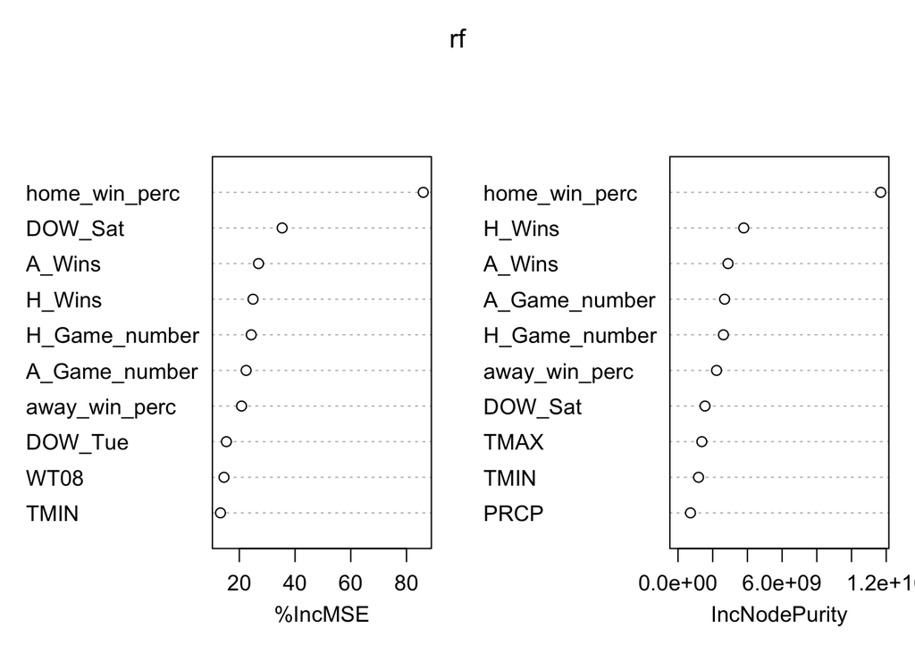

```r
varImpPlot(rf, n.var =10)
```

```r
model.rf.predictions <- predict(rf, test)
model.rf.predictions <- as.integer(round(model.rf.predictions))
oosmae_rf <- abs((test$Attendance-model.rf.predictions))
summary(oosmae_rf)
```

```
##    Min. 1st Qu.  Median    Mean 3rd Qu.    Max.
##      18    1473    3052    3827    5308   25554
```

```r
oosmse_rf <- mean((test$Attendance-model.rf.predictions)^2)
summary(oosmse_rf)
```

```
##     Min.  1st Qu.   Median     Mean  3rd Qu.     Max.
## 25738773 25738773 25738773 25738773 25738773 25738773
```

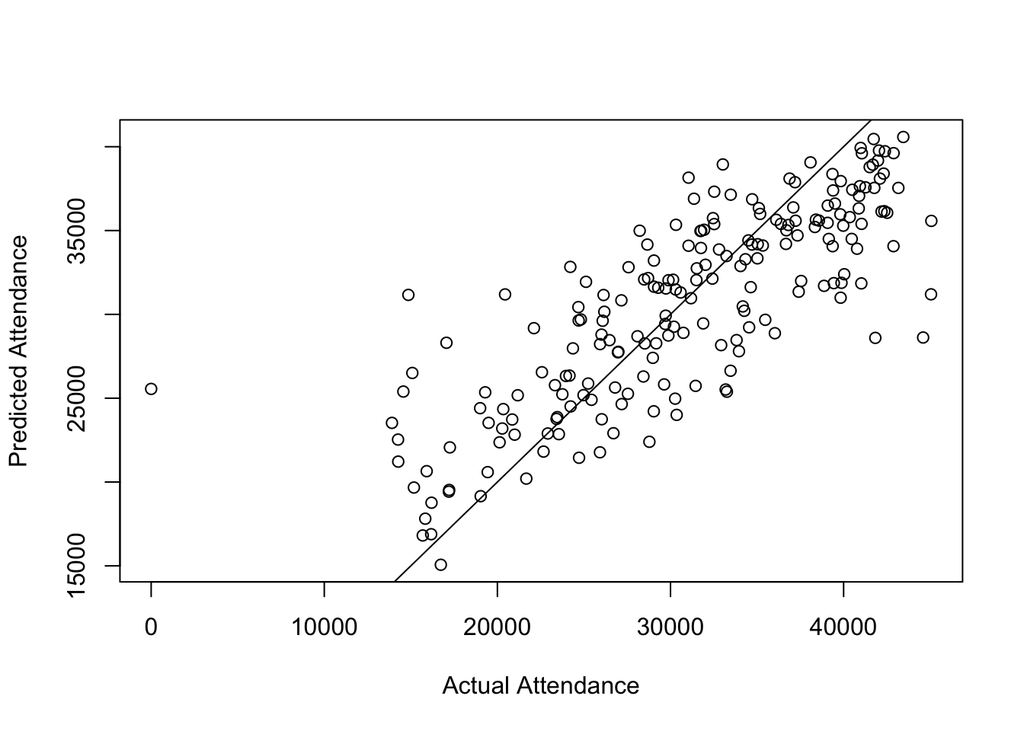

```r
rf_pred_error <- test$Attendance-model.rf.predictions

rf_within_3000 <- sum(ifelse(abs(model.rf.predictions-test$Attendance)<=3000,1,0))/nrow(test)

plot(x=test$Attendance, y=model.rf.predictions,
       xlab="Actual Attendance", ylab="Predicted Attendance")
  abline(a=0,b=1)
```

About 49.26% of attendance predictions were within 3000 attendees of the actual attendance.

This model has a MAE of 3826.586 and MSE of 2.573877310^{7}

```r
#SVM Model
library(kernlab)
model.1 <- ksvm(Attendance ~ ., data = train,
                          kernel = "polydot", type = "eps-bsvr")
# look at basic information about the model
model.1
```

```
## Support Vector Machine object of class "ksvm"
##
## SV type: eps-bsvr
## Polynomial kernel function.
##  Hyperparameters : degree =  1  scale =  1  offset =  1
##
## Number of Support Vectors : 532
##
## Objective Function Value : -225.3291
## Training error : 0.393216
```

```r
## Step 3: Evaluating model performance
# predictions on testing dataset
model.1.predictions <- predict(model.1, test)
model.1.predictions <- as.integer(round(model.1.predictions))
oosmae_svm <- abs((test$Attendance-model.1.predictions))
summary(oosmae_svm)
```

```
##    Min. 1st Qu.  Median    Mean 3rd Qu.    Max.
##      22    1316    3411    4117    5946   24992
```

```r
oosmse_svm <- mean((test$Attendance-model.1.predictions)^2)
summary(oosmse_svm)
```

```
##     Min.  1st Qu.   Median     Mean  3rd Qu.     Max.
## 31305544 31305544 31305544 31305544 31305544 31305544
```

```r
svm_pred_error <- test$Attendance-model.1.predictions
svm_within_3000 <- round(length(svm_pred_error[svm_pred_error >= -3000 & svm_pred_error <=3000])/length(svm_pred_error),2)
svm_within_3000*100
```

```
## [1] 46
```

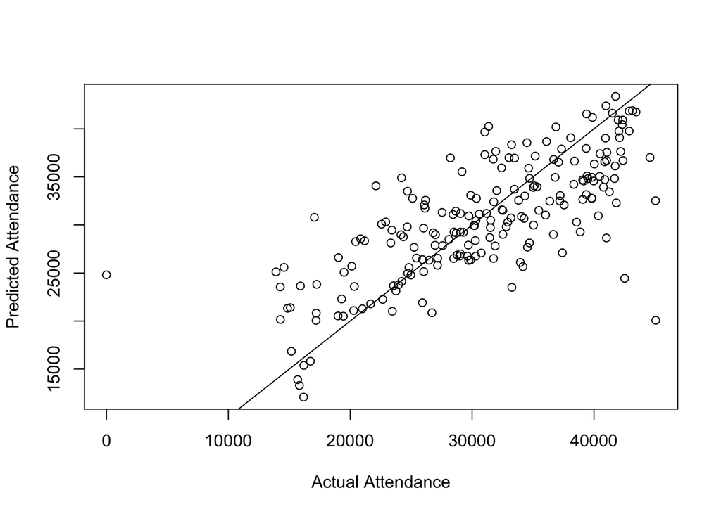

```r
plot(x=test$Attendance, y=model.1.predictions,
       xlab="Actual Attendance", ylab="Predicted Attendance")
  abline(a=0,b=1)
```

```r
lmsvm_model <- lm(test$Attendance~model.1.predictions)
summary(lmsvm_model)
```

```
##
## Call:
## lm(formula = test$Attendance ~ model.1.predictions)
##
## Residuals:
##      Min       1Q   Median       3Q      Max
## -25192.8  -3034.0    218.3   3281.8  24560.4
##
## Coefficients:
##                      Estimate Std. Error t value Pr(>|t|)
## (Intercept)          634.5628  1989.4644   0.319     0.75
## model.1.predictions    0.9899     0.0638  15.516   <2e-16 ***
## ---
## Signif. codes:  0 '***' 0.001 '**' 0.01 '*' 0.05 '.' 0.1 ' ' 1
##
## Residual standard error: 5613 on 201 degrees of freedom
## Multiple R-squared:  0.545,  Adjusted R-squared:  0.5427
## F-statistic: 240.7 on 1 and 201 DF,  p-value: < 2.2e-16
```

About 46% of attendance predictions were within 3000 attendees of the actual attendance.

This model has a MAE of 4116.512 and MSE of 3.130554410^{7}

```r
## GLM Model
glm_p <- glm(Attendance~.,family = poisson,data=train)

summary(glm_p)
```

```
##
## Call:
## glm(formula = Attendance ~ ., family = poisson, data = train)
##
## Deviance Residuals:
##      Min        1Q    Median        3Q       Max
## -179.241   -17.409    -0.439    19.330    98.911
##
## Coefficients: (4 not defined because of singularities)
##                 Estimate Std. Error  z value Pr(>|z|)
## (Intercept)    9.816e+00  4.091e-03 2399.409  < 2e-16 ***
## H_Game_number -1.013e-02  1.684e-04  -60.145  < 2e-16 ***
## A_Game_number -9.369e-04  1.625e-04   -5.767 8.06e-09 ***
## H_Wins         2.254e-02  5.241e-05  430.114  < 2e-16 ***
## A_Wins         9.492e-04  4.843e-05   19.598  < 2e-16 ***
## PRCP          -2.757e-02  9.126e-04  -30.205  < 2e-16 ***
## TMAX           4.302e-03  4.543e-05   94.703  < 2e-16 ***
## TMIN           1.768e-03  5.111e-05   34.591  < 2e-16 ***
## WT01          -4.911e-03  5.872e-04   -8.364  < 2e-16 ***
## WT03          -4.262e-02  8.523e-04  -50.008  < 2e-16 ***
## WT07          -2.301e-02  1.342e-03  -17.146  < 2e-16 ***
## WT08          -8.146e-02  5.868e-04 -138.811  < 2e-16 ***
## WT16           3.137e-02  7.396e-04   42.415  < 2e-16 ***
## WT18           2.224e-01  3.547e-03   62.715  < 2e-16 ***
## DOW_Fri        1.833e-01  9.195e-04  199.335  < 2e-16 ***
## DOW_Mon        5.464e-03  1.082e-03    5.049 4.44e-07 ***
## DOW_Sat        2.532e-01  8.908e-04  284.270  < 2e-16 ***
## DOW_Sun        1.033e-01  9.973e-04  103.619  < 2e-16 ***
## DOW_Thu        8.601e-02  1.015e-03   84.753  < 2e-16 ***
## DOW_Tue       -4.830e-03  9.319e-04   -5.183 2.18e-07 ***
## DOW_Wed               NA         NA       NA       NA
## DH_Game_0      1.417e-02  1.710e-03    8.290  < 2e-16 ***
## DH_Game_1     -1.053e-01  2.382e-03  -44.192  < 2e-16 ***
## DH_Game_2             NA         NA       NA       NA
## Away_ANA      -2.121e-03  2.678e-03   -0.792  0.42824
## Away_ARI       5.663e-02  3.869e-03   14.636  < 2e-16 ***
## Away_ATL       2.176e-01  6.002e-03   36.251  < 2e-16 ***
## Away_BAL      -1.169e-01  2.825e-03  -41.375  < 2e-16 ***
## Away_BOS       1.110e-01  2.699e-03   41.113  < 2e-16 ***
## Away_CHA      -2.495e-02  2.624e-03   -9.506  < 2e-16 ***
```

[output cut: 22 more lines]

```
## Game_Time_D    7.647e-02  6.873e-04  111.260  < 2e-16 ***
## Game_Time_N           NA         NA       NA       NA
## home_win_perc -7.316e-02  4.071e-03  -17.973  < 2e-16 ***
## away_win_perc -5.369e-02  3.185e-03  -16.859  < 2e-16 ***
## top_starter    2.865e-02  5.535e-04   51.758  < 2e-16 ***
## ---
## Signif. codes:  0 '***' 0.001 '**' 0.01 '*' 0.05 '.' 0.1 ' ' 1
##
## (Dispersion parameter for poisson family taken to be 1)
##
##     Null deviance: 1353400  on 605  degrees of freedom
## Residual deviance:  527163  on 553  degrees of freedom
## AIC: 534616
##
## Number of Fisher Scoring iterations: 4
```

```r
glm_pred <- predict(glm_p,newdata = test,type="response")
```

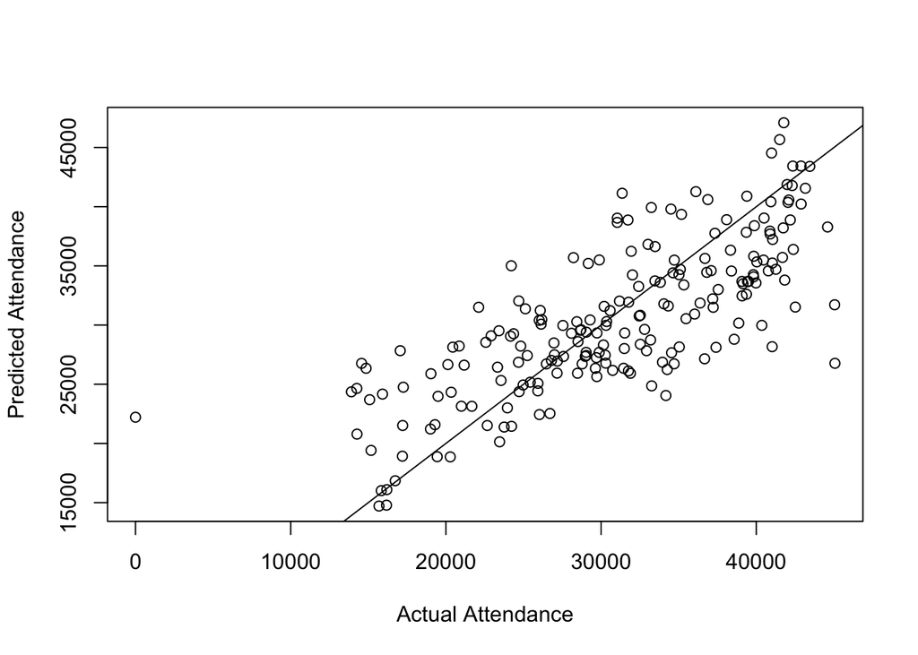

```r
glm_within_3000 <- sum(ifelse(abs(glm_pred-test$Attendance)<3000,1,0))/nrow(test)

glm_MAE <- mean(abs(glm_pred-test$Attendance))

glm_MSE <- mean((glm_pred-test$Attendance)^2)

plot(x=test$Attendance, y=glm_pred,
       xlab="Actual Attendance", ylab="Predicted Attendance")
  abline(a=0,b=1)
```

About 44.33% of attendance predictions were within 3000 attendees of the actual attendance.

This model has a MAE of 4143.356 and MSE of 2.910906510^{7}

```r
# Linear


linmodel = lm(Attendance ~ ., data = train)

anslin = predict(linmodel, newdata=test)
# ============================================
#  Number of games within 3000 for linear model
# ============================================
difference = abs(test$Attendance - anslin)
lm_within_3000 <- sum(ifelse(difference > 3000, 0,1))/nrow(test)


# ============================================
#  MAE for linear model
# ============================================
lm_MAE <- mean(difference)
lm_MSE <- mean((test$Attendance - anslin)^2)
```

About 44.83% of attendance predictions were within 3000 attendees of the actual attendance.

This model has a MAE of 4131.459 and MSE of 2.797178210^{7}

```r
# Decision trees

library(C50)
att_id <- as.numeric((grep("Attendance", colnames(train))))
dtree_model <- C5.0(train[-att_id],as.factor(train$Attendance))
anstree<- predict(dtree_model, test)
anstree = as.numeric(as.character(anstree))


# ============================================
#  Number of games within 3000 for dtree model
# ============================================
difftree = abs(test$Attendance - anstree)
tree_within_3000 <- sum(ifelse(difftree > 3000, 0,1))/nrow(test)


# ============================================
#  MAE for dtree model
# ============================================
tree_MAE <- mean(difftree)
tree_MSE <- mean((test$Attendance - anstree)^2)
```

About 17.24% of attendance predictions were within 3000 attendees of the actual attendance.

This model has a MAE of 8269.833 and MSE of 1.021159710^{8}

```r
voting <- (1/6*glm_pred+.5*model.rf.predictions+1/6*model.1.predictions+1/6*anslin)

vote_within_3000 <- sum(ifelse(abs(voting-test$Attendance)<3000,1,0))/nrow(test)

vote_MAE <- mean(abs(voting-test$Attendance))
vote_MSE <- mean((voting-test$Attendance)^2)
```

About 46.8% of attendance predictions were within 3000 attendees of the actual attendance.

This model has a MAE of 3724.305 and MSE of 2.433775910^{7}

#Summary

##Random Forest

About 49.26% of attendance predictions were within 3000 attendees of the actual attendance.

This model has a MAE of 3826.586 and MSE of 2.573877310^{7}

##SVM

About 46% of attendance predictions were within 3000 attendees of the actual attendance.

This model has a MAE of 4116.512 and MSE of 3.130554410^{7}

##GLM

About 44.33% of attendance predictions were within 3000 attendees of the actual attendance.

This model has a MAE of 4143.356 and MSE of 2.910906510^{7}

##LM

About 44.83% of attendance predictions were within 3000 attendees of the actual attendance.

This model has a MAE of 4131.459 and MSE of 2.797178210^{7}

##Decision Tree

About 17.24% of attendance predictions were within 3000 attendees of the actual attendance.

This model has a MAE of 8269.833 and MSE of 1.021159710^{8}

##Voting

About 46.8% of attendance predictions were within 3000 attendees of the actual attendance.

This model has a MAE of 3724.305 and MSE of 2.433775910^{7}

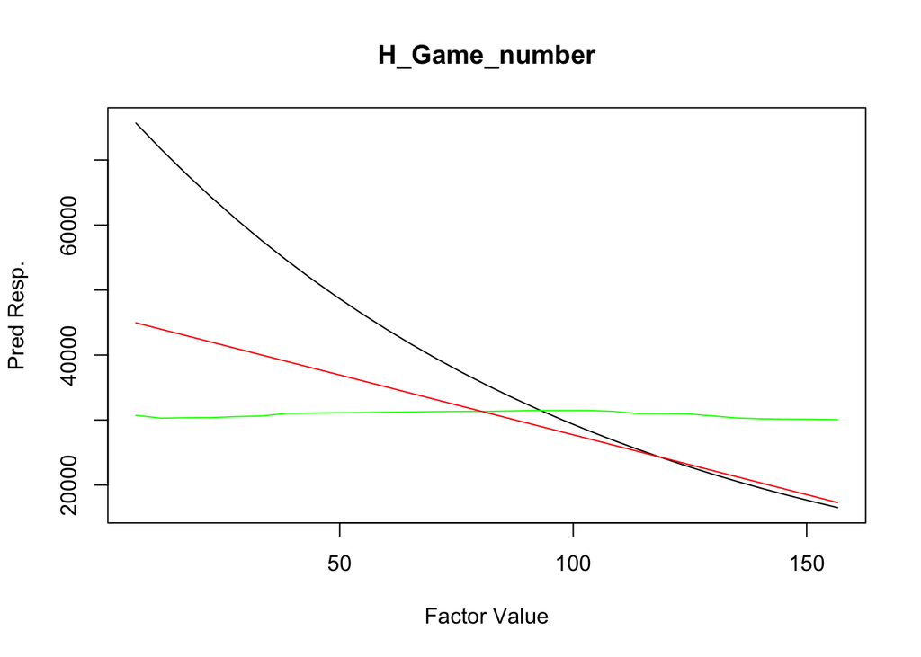

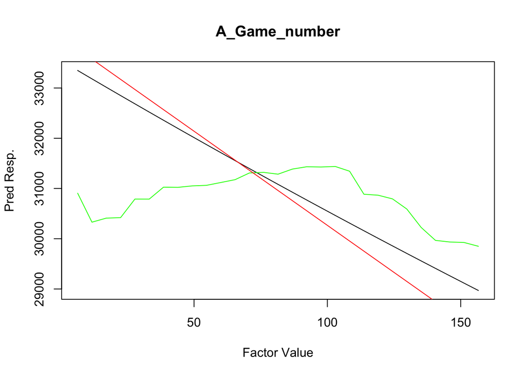

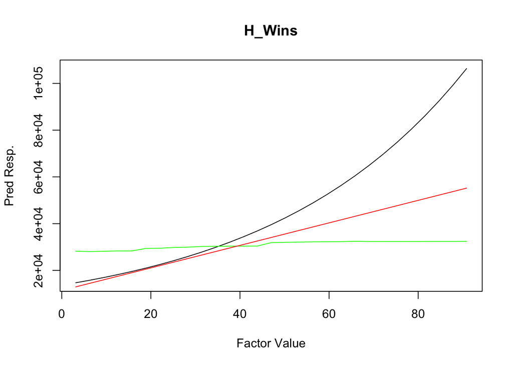

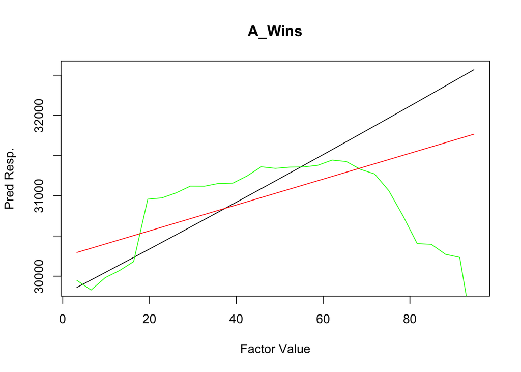

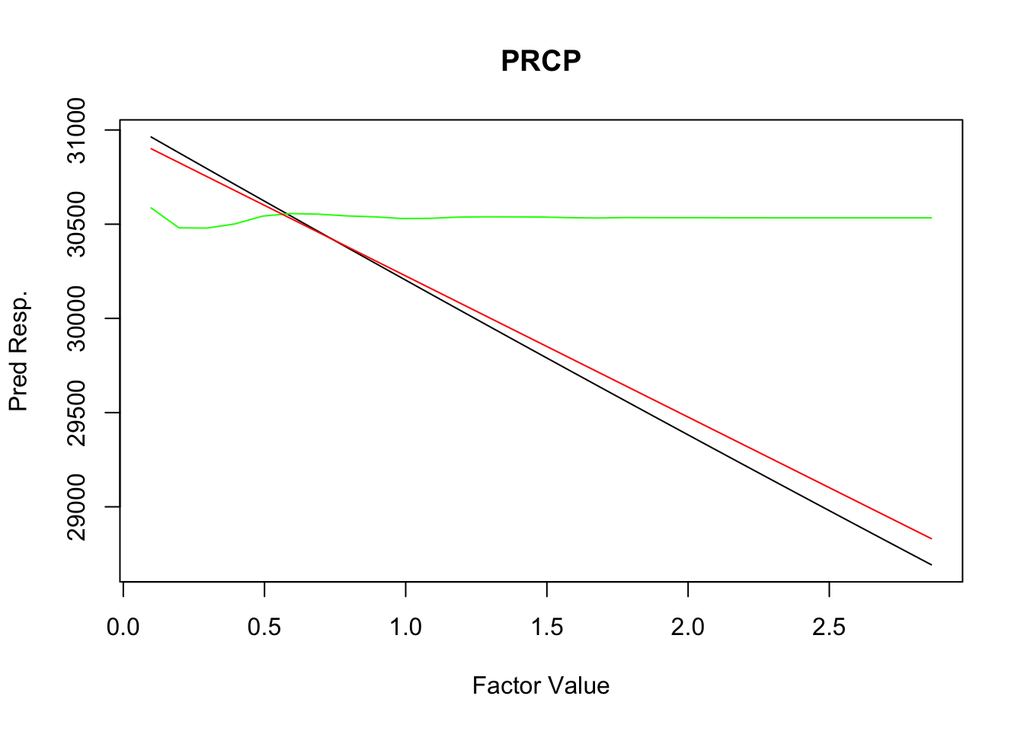

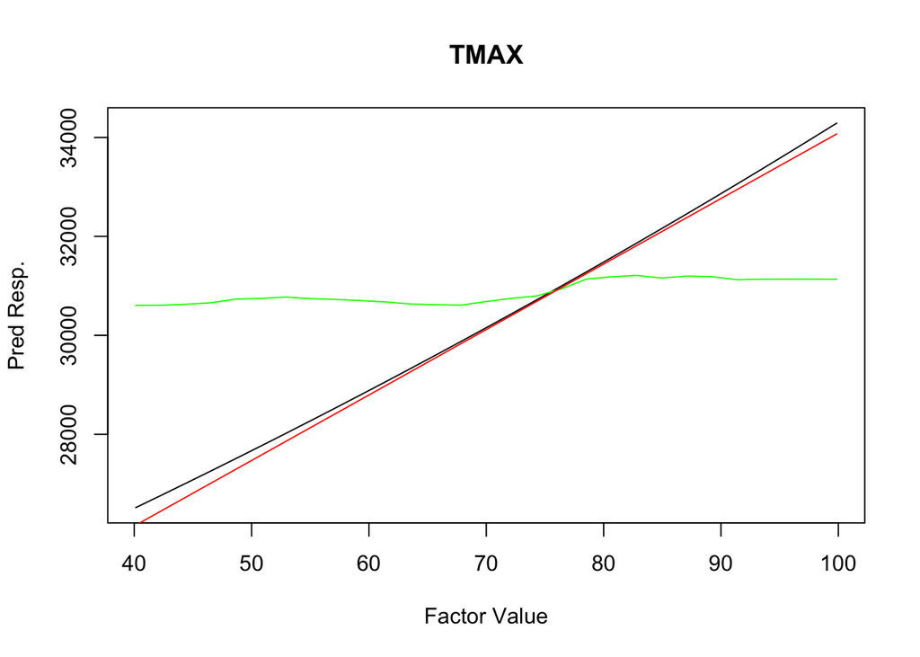

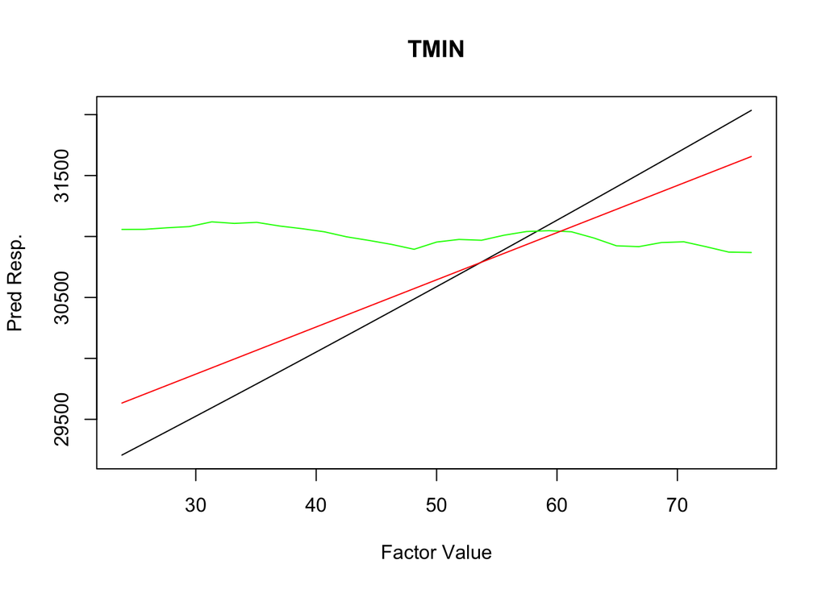

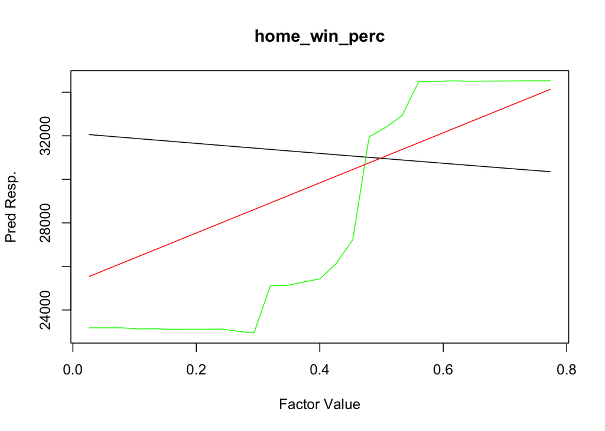

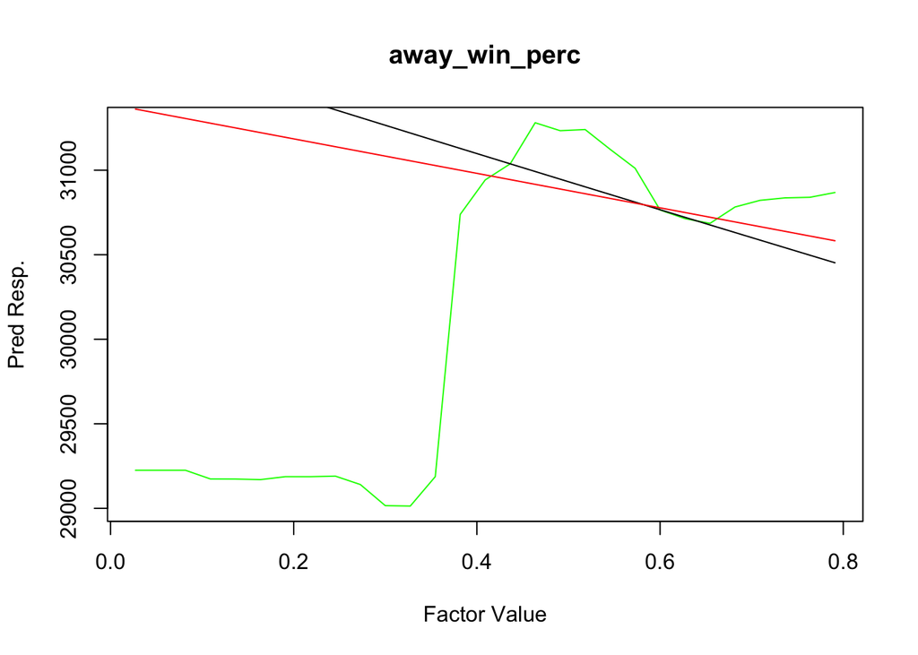

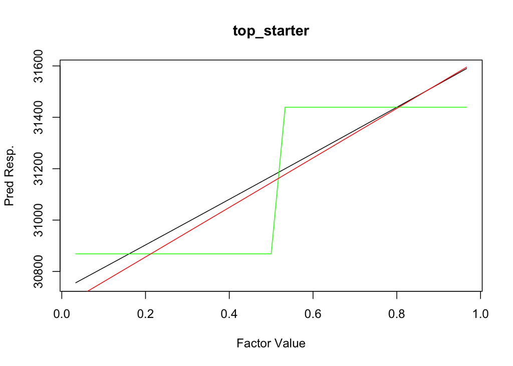

```r
#PDP

steps = 30
f_hat <- matrix(0,steps+1,4)
for(x in c(1:7,54:56)){
  f_hat <- matrix(0,steps+1,4)
  plot_data <- train[-5]
  x_max <- max(plot_data[,x])
  x_min <- min(plot_data[,x])
  j= x_min
  r=1
  while(j <= x_max){
    plot_data[,x] = j
    tmp_rf = predict(rf,newdata = plot_data,type="response")
    tmp_glm = predict(glm_p,newdata = plot_data,type="response")
    tmp_svm =  predict(model.1, plot_data)
    f_hat[r,1] = j
    f_hat[r,2] = mean(tmp_rf)
    f_hat[r,3] = mean(tmp_glm)
    f_hat[r,4] = mean(tmp_svm)

    j = j + (x_max-x_min)/steps
    r=r+1
  }
  if(x == 54 || x == 55){
    plot(f_hat[2:steps,1],f_hat[2:steps,2], type = "l" , col = "green", main = colnames(plot_data[x]), xlab = "Factor Value", ylab = "Pred Resp." )
  lines(f_hat[2:steps,1],f_hat[2:steps,3], type = "l" ,col = "black", main = colnames(plot_data[x]), xlab = "Factor Value", ylab = "Pred Resp." )
  lines(f_hat[2:steps,1],f_hat[2:steps,4], type = "l" ,col = "red", main = colnames(plot_data[x]), xlab = "Factor Value", ylab = "Pred Resp." )
  }else{
  plot(f_hat[2:steps,1],f_hat[2:steps,3], type = "l" , main = colnames(plot_data[x]), xlab = "Factor Value", ylab = "Pred Resp." )
  lines(f_hat[2:steps,1],f_hat[2:steps,2], type = "l" ,col = "green", main = colnames(plot_data[x]), xlab = "Factor Value", ylab = "Pred Resp." )
  lines(f_hat[2:steps,1],f_hat[2:steps,4], type = "l" ,col = "red", main = colnames(plot_data[x]), xlab = "Factor Value", ylab = "Pred Resp." )
  }
}
```